# step 4 visualize results

Zachary Amir

2025-11-07 12:53:31.928116

## Introduction

This Rmarkdown file will be used to generate all key plots included in the main and supplementary text of our manuscript. Additional plots will likely be generated as well, but only the key plots will be visualized in this document.

## Histograms

Histograms are a key tool for visualizing the results from many co-abundance models, by examining the count of different species interaction values (SIV) from different levels of support. Below you will see the key plots generated in this document, following the support criteria defined in step 3. Note that additional plots with more conservative PPC settings (matching those of Amir et al 2022, Ecology & Evolution) will be saved to dropbox but not visualized in this document.

Importantly, histograms can be generated on a per model (i.e., each species pair has a top-down or bottom-up model), or per species pair (i.e., each pair is either top-down, bottom-up, or unsupported). **The histograms below have been calculated per species-pairs.**

The first plot visualized the conceptual outcome of our hypotheses. If our top-down hypothesis is supported, then the majority of SIVs would be significant and negative. If our bottom-up hypothesis is supported, then the majority of SIVs would be significant and positive.

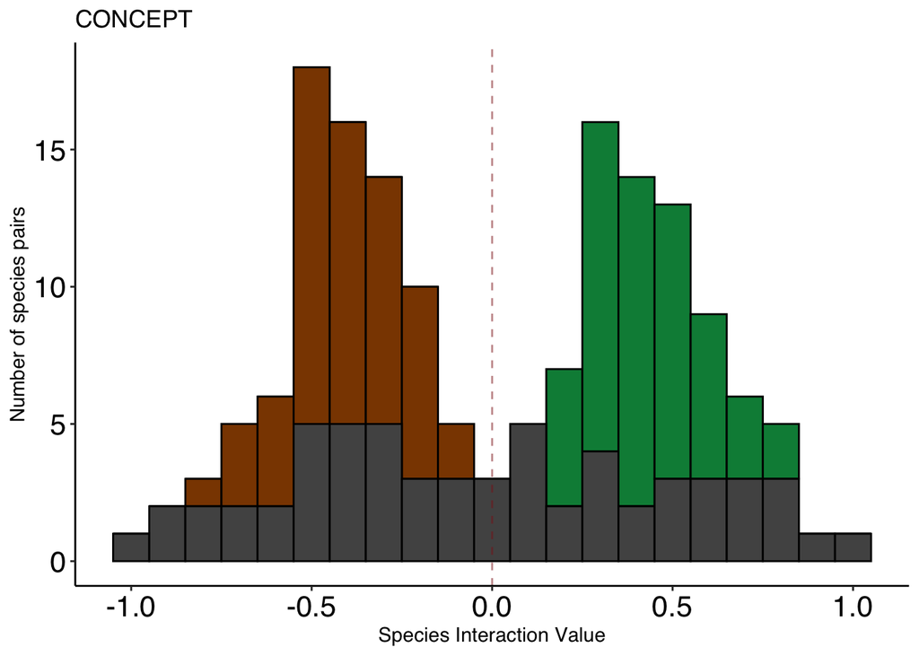

The next plot is the pooled results from **preferred predator prey models** where all models are combined into a single histogram. The supported top-down results include 2 models, which is 6.2 percent of the available models. The supported bottom-up results include 12 models, which is 37.5 percent of the available models. Finally, the unsupported results include 18 models, which is 56.2 percent of the available models.

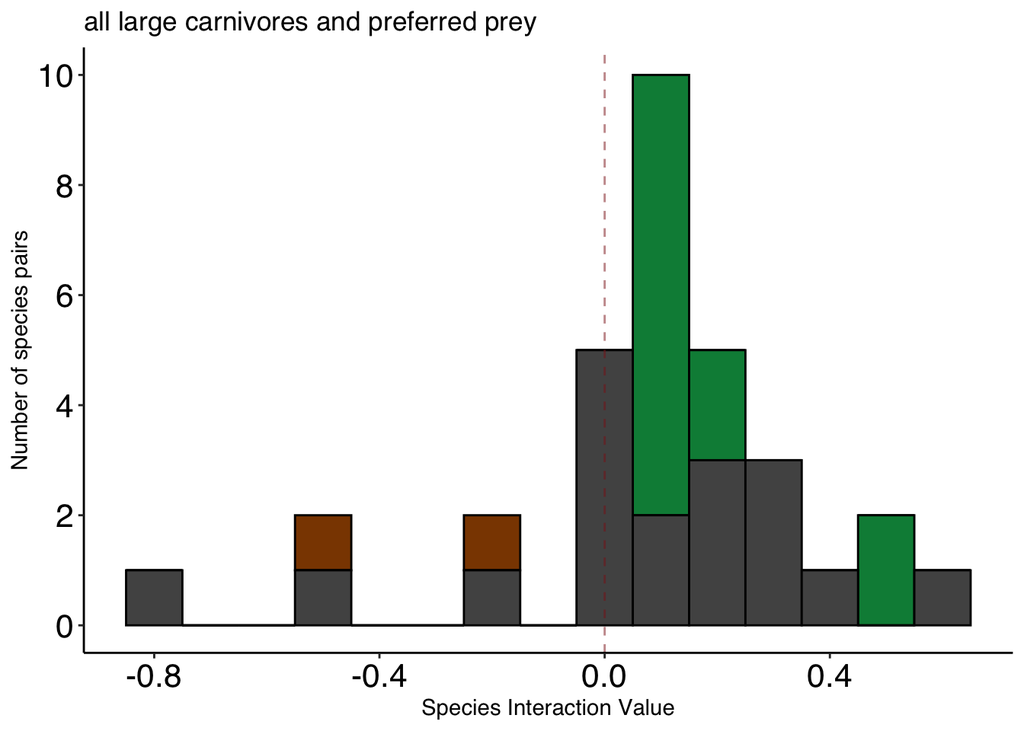

The next plot includes all of the preferred predator prey models (same as above), but this time split between the four large carnivore species.

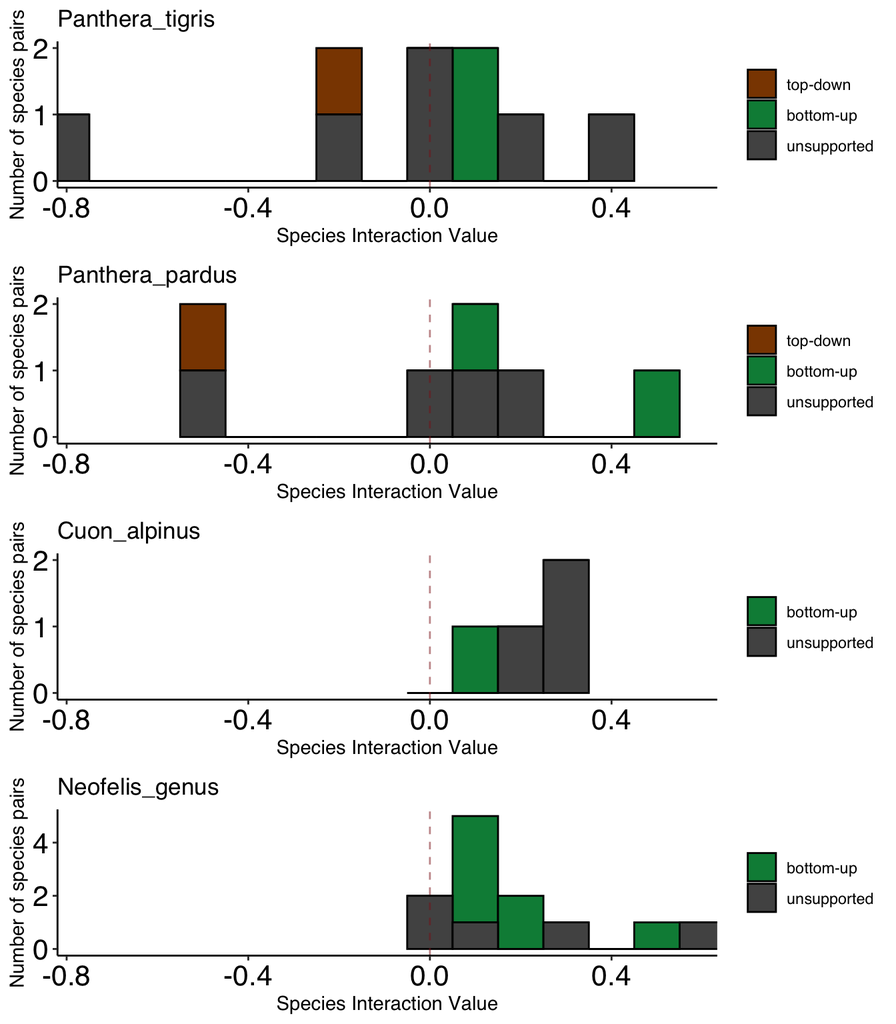

The next plot is the pooled results from **all predator prey models across the community** where all models are combined into a single histogram. The supported top-down results include 16 models, which is 11.2 percent of the available models. The supported bottom-up results include 29 models, which is 20.3 percent of the available models. Finally, the unsupported results include 98 models, which is 68.5 percent of the available models.

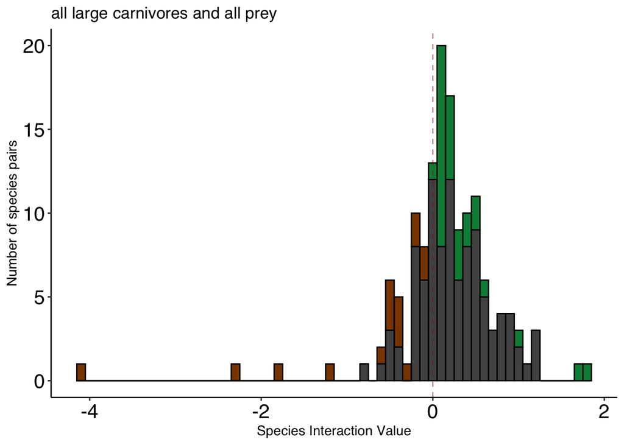

The next plot includes all predator prey models across the community (same as above), but this time split between the four large carnivore species.

- The results for Panthera_tigris include 8 supported top-down models (22.9%), 5 supported bottom-up models (14.3%), and 22 unsupported models (62.9%).
- The results for Panthera_pardus include 3 supported top-down models (9.7%), 6 supported bottom-up models (19.4%), and 22 unsupported models (71%).
- The results for Cuon_alpinus include 4 supported top-down models (11.8%), 5 supported bottom-up models (14.7%), and 25 unsupported models (73.5%).
- The results for Neofelis_genus include 1 supported top-down models (2.3%), 13 supported bottom-up models (30.2%), and 29 unsupported models (67.4%).

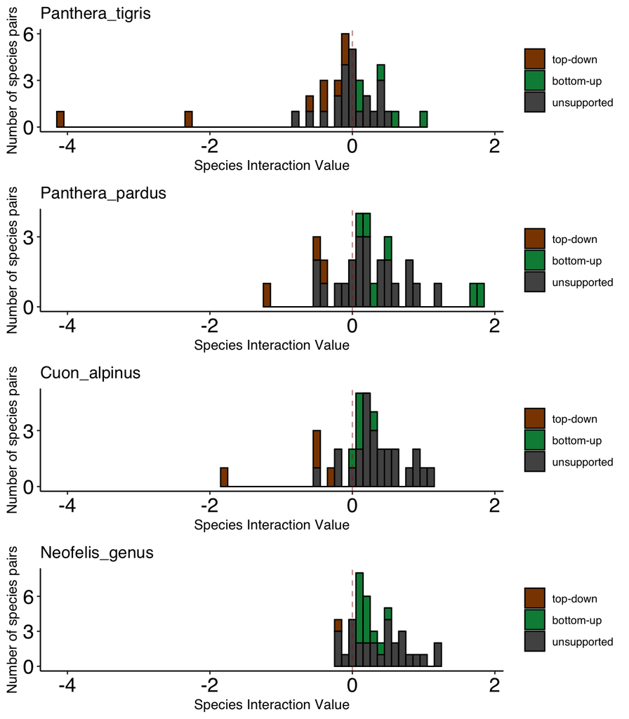

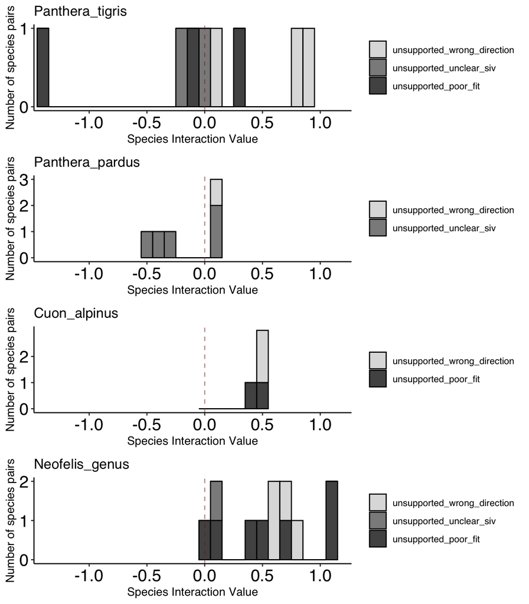

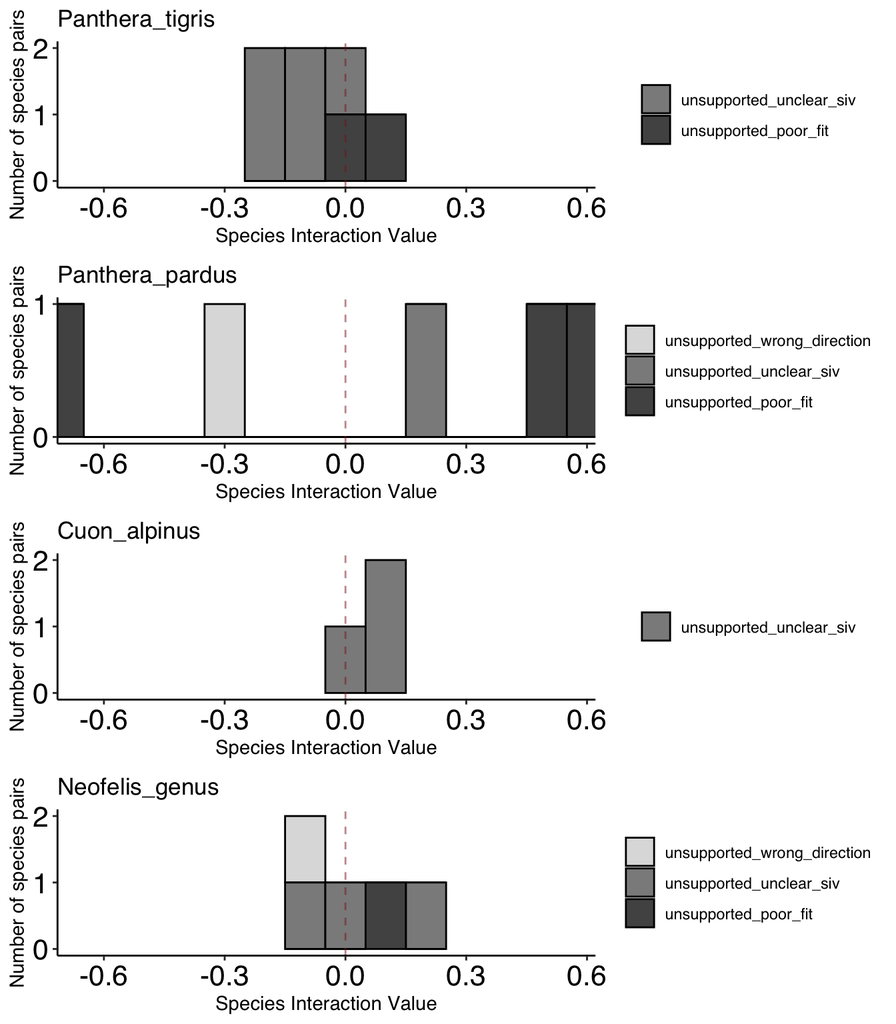

## Counter-factual histograms

Below is a graph of the SIVs from 5 counter-factual tests, and compared with the original results presented above. As a reminder, all counter-factual tests only include preferred predator-prey co-abundance models.

- For the counter-factual test original_test, there were 2 supported top-down models (3.1%), 12 supported bottom-up models (18.8%), and 50 unsupported models (78.1%).
- For the counter-factual test site_matching_ThaiEFC, there were 1 supported top-down models (2.5%), 10 supported bottom-up models (25%), and 29 unsupported models (72.5%).
- For the counter-factual test isolate_extirpations, there were 3 supported top-down models (4.7%), 12 supported bottom-up models (18.8%), and 49 unsupported models (76.6%).
- For the counter-factual test isolate_altitude, there were 4 supported top-down models (6.2%), 12 supported bottom-up models (18.8%), and 48 unsupported models (75%).
- For the counter-factual test isolate_FLII, there were 2 supported top-down models (3.1%), 11 supported bottom-up models (17.2%), and 51 unsupported models (79.7%).
- For the counter-factual test isolate_HFP, there were 4 supported top-down models (6.2%), 11 supported bottom-up models (17.2%), and 49 unsupported models (76.6%).

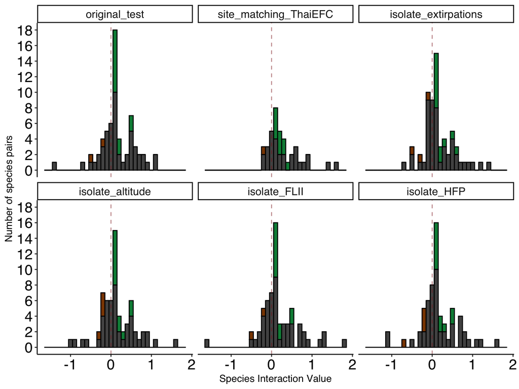

## Save plots & data

The plots and data used to inform this document are saved in the GitHub Repository here: `figures/step4_output_figs/` & `figures/step4_output_summarized_results_for_figs/`.